# Session 1

## Matrices

Matrix is a collection of elements of the same data type arranged into a fixed number of rows and columns. The length of columns should be equal.

### Creating

You can create a matrix with matrix().

```r
vec <- c(1:10)
matrix(data = vec, nrow = 5, ncol = 2, byrow = FALSE)
```

```
##      [,1] [,2]
## [1,]    1    6
## [2,]    2    7
## [3,]    3    8
## [4,]    4    9
## [5,]    5   10
```

```r
matrix(data = vec, nrow = 5, ncol = 2, byrow = TRUE)
```

```
##      [,1] [,2]
## [1,]    1    2
## [2,]    3    4
## [3,]    5    6
## [4,]    7    8
## [5,]    9   10
```

The mentioned functions in the data frame part can be used for matrices.

## Lists

Lists are ordered collections of any R object. It stores different types of elements. Collections can have different lengths despite matrices and data frames.

### Creating

You can create a list with the list(). Syntax: list(object1, object2, object3, …)

```r
vec <- c(1:10)
mat <- matrix(vec, nrow = 5, ncol = 2)
fac <- factor(c("blue", "red", "blue", "yellow"))
l <- list(numbers_vec = vec, numbers_mat = mat, colors = fac)
l
```

```
## $numbers_vec
##  [1]  1  2  3  4  5  6  7  8  9 10
##
## $numbers_mat
##      [,1] [,2]
## [1,]    1    6
## [2,]    2    7
## [3,]    3    8
## [4,]    4    9
## [5,]    5   10
##
## $colors
## [1] blue   red    blue   yellow
## Levels: blue red yellow
```

### Selecting Elements

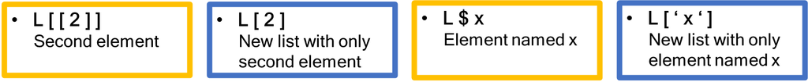

```r
l[[2]]
```

```
##      [,1] [,2]
## [1,]    1    6
## [2,]    2    7
## [3,]    3    8
## [4,]    4    9
## [5,]    5   10
```

```r
l[2]
```

```
## $numbers_mat
##      [,1] [,2]
## [1,]    1    6
## [2,]    2    7
## [3,]    3    8
## [4,]    4    9
## [5,]    5   10
```

```r
l$colors
```

```
## [1] blue   red    blue   yellow
## Levels: blue red yellow
```

```r
l['colors']
```

```
## $colors
## [1] blue   red    blue   yellow
## Levels: blue red yellow
```

## Converting

You can convert data structures to each other by functions.

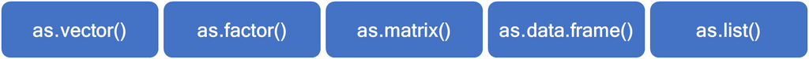

```r
df <- data.frame(col_1 = c(1:3),
                 col_2 = c(4:6))
df
```

```
##   col_1 col_2
## 1     1     4
## 2     2     5
## 3     3     6
```

```r
mat <- as.matrix(df)
mat
```

```
##      col_1 col_2
## [1,]     1     4
## [2,]     2     5
## [3,]     3     6
```

```r
l <- as.list(mat)
l
```

```
## [[1]]
## [1] 1
##
## [[2]]
## [1] 2
##
## [[3]]
## [1] 3
##
## [[4]]
## [1] 4
##
## [[5]]
## [1] 5
##
## [[6]]
## [1] 6
```

```r
vec_mat <- as.vector(mat)
vec_mat
```

```
## [1] 1 2 3 4 5 6
```

```r
fac <- as.factor(vec_mat)
fac
```

```
## [1] 1 2 3 4 5 6
## Levels: 1 2 3 4 5 6
```

```r
df <- as.data.frame(l)
df
```

```
##   X1L X2L X3L X4L X5L X6L
## 1   1   2   3   4   5   6
```

**Q_1:** When we convert a data frame or a matrix to a list, we miss the column names. Is it possible to assign the column names to the list elements?

Yes, you can use the names().

```r
names(l) <- colnames(mat)
l
```

```
## $col_1
## [1] 1
##
## $col_2
## [1] 2
##
## $<NA>
## [1] 3
##
## $<NA>
## [1] 4
##
## $<NA>
## [1] 5
##
## $<NA>
## [1] 6
```

However, you cannot assign the column names directly. It cannot recognise the elements of each column. So we need to define the names by ourselves.

```r
names(l) <- rep(colnames(mat), each = 3)
l
```

```
## $col_1
## [1] 1
##
## $col_1
## [1] 2
##
## $col_1
## [1] 3
##
## $col_2
## [1] 4
##
## $col_2
## [1] 5
##
## $col_2
## [1] 6
```

**Q_2:** Is it possible to convert any type of object to another?

No, sometimes converting two-dimensional data structures to single-dimensional data structures is impossible. For example, you cannot convert a data frame or a list to a vector.

```r
vec_df <- as.vector(df)
vec_df
```

```
## $X1L
## [1] 1
##
## $X2L
## [1] 2
##
## $X3L
## [1] 3
##
## $X4L
## [1] 4
##
## $X5L
## [1] 5
##
## $X6L
## [1] 6
```

```r
vec_l <- as.vector(l)
vec_l
```

```
## $col_1
## [1] 1
##
## $col_1
## [1] 2
##
## $col_1
## [1] 3
##
## $col_2
## [1] 4
##
## $col_2
## [1] 5
##
## $col_2
## [1] 6
```

# Defining a Function

You can write your own functions to make repetitive operations using a single command. Your function can return nothing and should be defined before using.

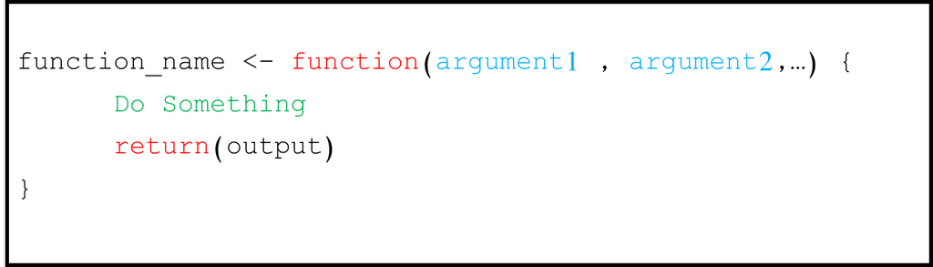

```r
# I want to write a function to add two numbers and check if their addition is more than 10. I want to get "Yes!" if it was, otherwise see a "No!" on my screen
check_more_than_10 <- function(num1, num2){
  if (num1 + num2 > 10){
    return("Yes!")
  } else {
    return("No!")
  }
}

result <- check_more_than_10(1, 4)
result
```

```
## [1] "No!"
```

# Naming Objects and Functions

- Object names must start with a letter, and can only contain letters, numbers, underscore (_), and dot (.).
- The name of an object should be meaningful and show its purpose clearly.
- There are different styles of naming objects, but it is recommended to use the snake_case style. In this style, each space is replaced by an underscore character, and the first letter of each word is written in lowercase.
- There are other ways to name objects.

  someUseUpperLettersToSeparateWords

  some.use.dots

Here are some tips for naming objects:

- Show what type of data structure your object is. For example, `cars_df` shows this object is a data frame.
- Start the name of logical variables with “is”. For example, `is_odd = TRUE`.
- Sometimes, you have to use a string or a number several times. For instance, you have a not ordered vector of numbers. You want to select numbers more than 10, but you are unsure if you want to change them later, and you used this condition many times in your code. It is better to define this value as a variable. Because if you decide to change the value, you don’t need to change it one by one. You will change the value. It is better to name it will all uppercase letters. Like `SELECTED_NUMS = 10`.
- Names should be meaningful, but you should not name them long. For instance, besides naming this: `up_regulated_genes_from_gsea_method_and_mesh_database_list`

  Use this: `up_gsea_mesh_l`
- Start function names with command verbs to separate them from other objects and variables.
- There are some reserved names in R. We call them keywords. For example, data.frame is a key word. You cannot name your objects similar to a reserved name. Because they will be overwritten and you will miss them.
- Have your own style in naming!

# Libraries and Packages

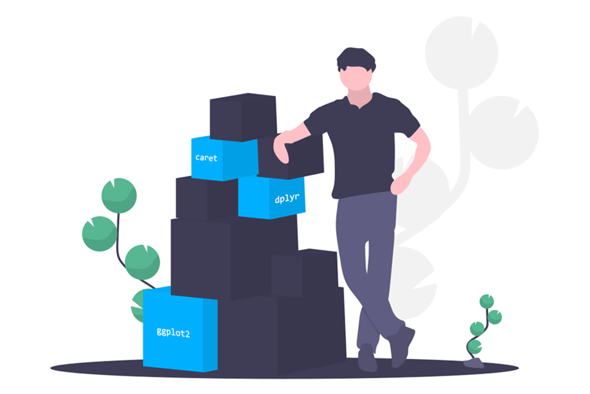

In R, a package is a collection of R functions and data. Packages are stored in libraries.

The tidyverse package is a collection of R packages designed for data science.

[figure not shown]

With library(), we can load the packages into the session and make their functions available.

```r
# install.packages("tidyverse)
library(tidyverse)
```

CRAN is a network of web servers around the world that store identical versions of code and documentation for R. You can install packages from CRAN by running `install.packages("package_name")`. However, you can install a CRAN package from the right panel of RStudio.

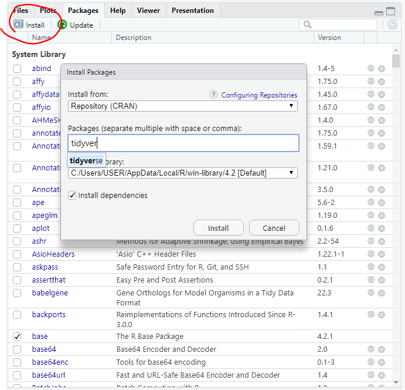

There are other ways to install a package. You can install it from GitHub or a .zip file on your computer.

You can install that package with this command:

`install.packages("file_path\\package_file_name.extension", repos = NULL, type = "source")`

Or, in the previous window, change the “install from” to Package Archive File.

You can install a package from GitHub. First, you need to install the devtools package.

`install.packages(devtools)`

Then you can use this command:

`devtools::install_github(account_name/repository_name)`